# HW2

# Найдите минимум, максимум, среднее и медиану полученных значений показателя.

```r
min(data$vacancy_rate)
```

```
## [1] NaN
```

```r
max(data$vacancy_rate)
```

```
## [1] NaN
```

```r
mean(data$vacancy_rate)
```

```
## [1] NaN
```

```r
median(data$vacancy_rate)
```

```
## [1] NA
```

# Постройте диаграмму уровня найма относительно медианы стоимости домов. Что можно заметить?

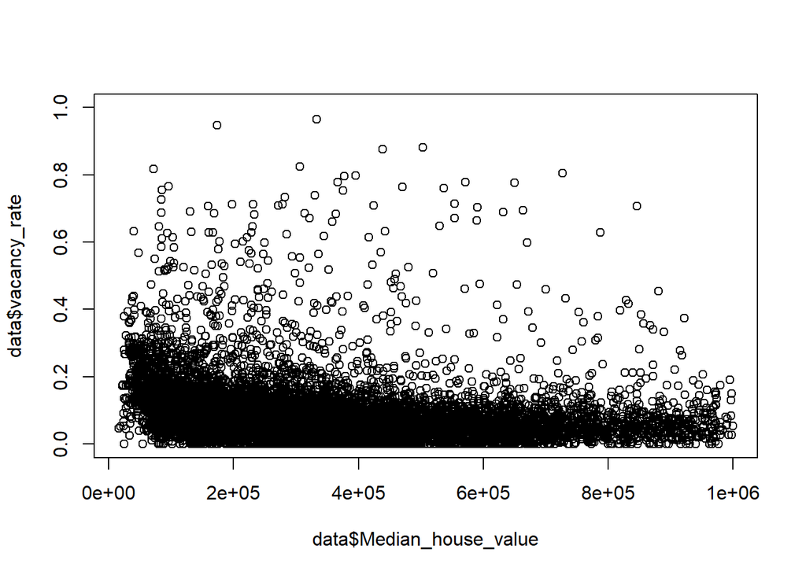

```r
plot(data$Median_house_value, data$vacancy_rate)
```

#По диаграме можно заметить, что чем больше средняя стоимость жилья, тем меньше уровень найма.

# Колонка COUNTYFP содержит числовой код округа внутри штата. Нас интересуют Butte County (округ 7 в Калифорнии), Santa Clara (округ 85 в Калифорнии) и York County (округ 133 в Пенсильвании).

# Объясните, что делает приведённый в конце задания код и как именно он это делает.

```r
acc <- c()
for (tract in 1:nrow(data)) {
#добавляем штат под цифрой 6 (Калифорния), в ней город 1 (Аламеда)
  if (data$STATEFP[tract] == 6) {
    if (data$COUNTYFP[tract] == 1) {
      acc <- c(acc, tract)
    }
  }
}
accmv <- c()
for (tract in acc) {
#заполняем вектор accmv значениями Median_house_value
  accmv <- c(accmv, data[tract,10])
}
#находим медиану полученного массива
median(accmv)
```

```
## [1] NA
```

# Напишите другим способом в одну строку, то же самое, что делает нижеуказанный код. Способов получить тот же ответ множество, достаточно одного.

```r
median(data$Median_house_value[data$STATEFP==6][data$COUNTYFP==1],na.rm=TRUE)
```

```
## [1] 473500
```

# Найдите средний процент построенных домовладений в округах (Butte County, Santa Clara, York County)

```r
CA_Index <- data$STATEFP == 6 #Код Калифорнии
CA_Household_Units <-  sum(data$Total_units[CA_Index])
PA_Index <- data$STATEFP == 42#Код Пенсильвании
PA_Household_Units <- sum(data$Total_units[PA_Index])
```

```r
##Butte County, CA
CA_BC_Index <- data$COUNTYFP == 7
mean(data$Total_units[CA_Index & CA_BC_Index] / CA_Household_Units, na.rm = TRUE)
```

```
## [1] 0.000137501
```

```r
##Santa Clara, CA
CA_SC_Index <- data$COUNTYFP == 85
mean(data$Total_units[CA_Index & CA_SC_Index] / CA_Household_Units, na.rm = TRUE)
```

```
## [1] 0.0001241324
```

```r
##York County, PA
PA_YC_Index <- data$COUNTYFP == 133
mean(data$Total_units[PA_Index & PA_YC_Index] / PA_Household_Units, na.rm = TRUE)
```

```
## [1] 0.0003555815
```

# Функция cor рассчитывает коэффициент корреляции между двумя переменными. Рассчитайте корреляцию между медианы стоимости домовладений (Median_house_value) и процентом построенных домов (Built_2005_or_later):

# для всего набора данных

```r
cor(as.numeric(data$Built_2005_or_later), data$Median_house_value)
```

```
## [1] NA
```

# для Калифорнии

```r
cor(as.numeric(data$Built_2005_or_later[CA_Index]), data$Median_house_value[CA_Index])
```

```
## [1] NA
```

# для Пенсильвании

```r
cor(as.numeric(data$Built_2005_or_later[PA_Index]), data$Median_house_value[PA_Index])
```

```
## [1] NA
```

# для округа Butte County

```r
cor(as.numeric(data$Built_2005_or_later[CA_Index & CA_BC_Index]), data$Median_house_value[CA_Index & CA_BC_Index])
```

```
## [1] 0.09716529
```

# для округа Santa Clara

```r
cor(as.numeric(data$Built_2005_or_later[CA_Index & CA_SC_Index]), data$Median_house_value[CA_Index & CA_SC_Index])
```

```
## [1] NA
```

# для округа York County

```r
cor(as.numeric(data$Built_2005_or_later[PA_Index & PA_YC_Index]), data$Median_house_value[PA_Index & PA_YC_Index])
```

```
## [1] 0.3561032
```

# Постройте три диаграммы медианы стоимости домовладений (Median_house_value) относительно медианы дохода (Median_household_income) для трёх округов. Допустимо указать все три на одном графике.

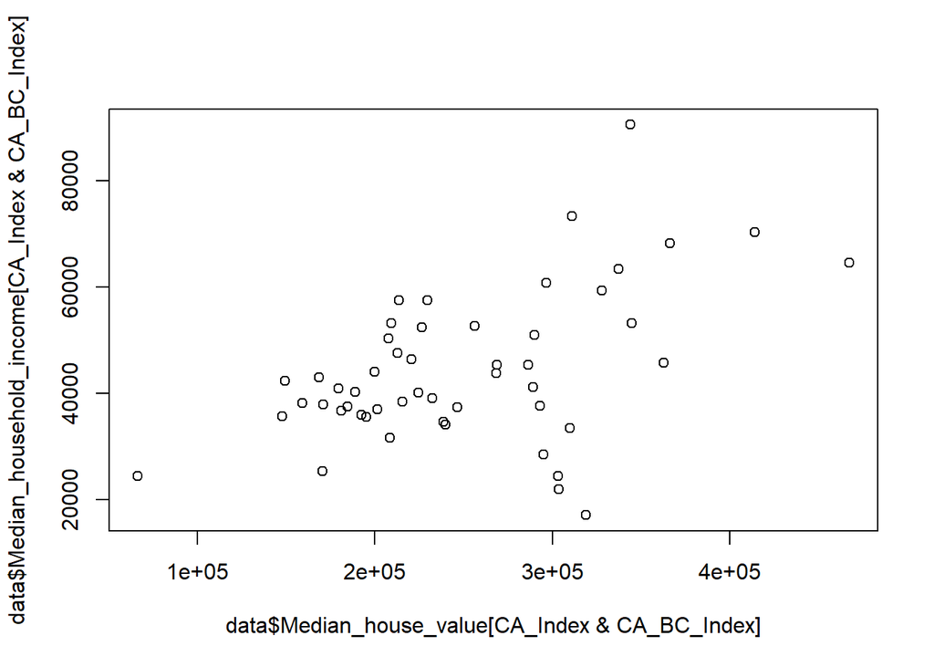

```r
plot( data$Median_house_value[CA_Index & CA_BC_Index], data$Median_household_income[CA_Index & CA_BC_Index])
```

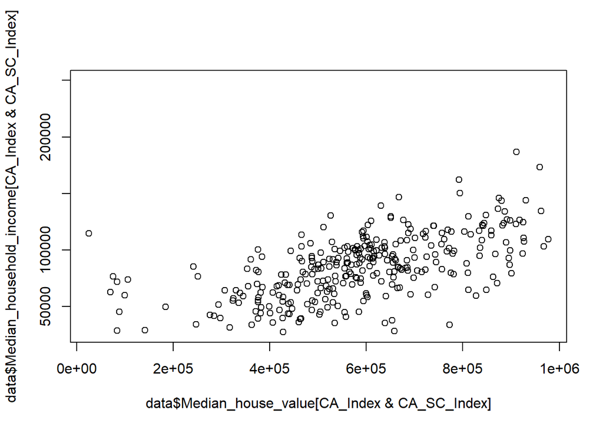

```r
plot( data$Median_house_value[CA_Index & CA_SC_Index], data$Median_household_income[CA_Index & CA_SC_Index])
```

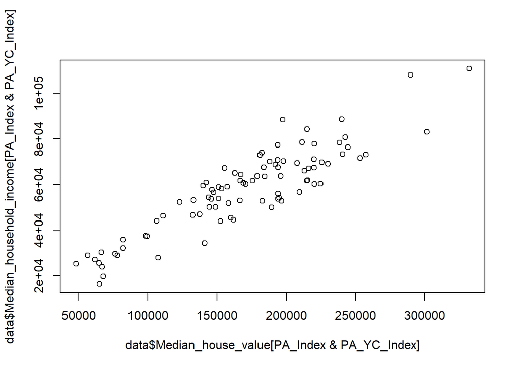

```r
plot( data$Median_house_value[PA_Index & PA_YC_Index], data$Median_household_income[PA_Index & PA_YC_Index])
```